# Análise Exploratória de Dados para Séries Temporais

### Grafico de dispersão

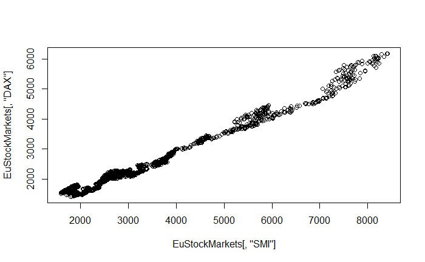

```r
plot(EuStockMarkets[, "SMI"], EuStockMarkets[, "DAX"])
```

```r
cor.test(EuStockMarkets[, "SMI"], EuStockMarkets[, "DAX"])
```

```
    Pearson's product-moment correlation

data:  EuStockMarkets[, "SMI"] and EuStockMarkets[, "DAX"]
t = 321.91, df = 1858, p-value < 2.2e-16
alternative hypothesis: true correlation is not equal to 0
95 percent confidence interval:
 0.9903155 0.9919199
sample estimates:
      cor
0.9911539
```

Como p_valor é menor que 0.05 rejeito h_0 e aceito que correlação entre as duas variaveis é estatisticamente significativa, onde, quanto maior o valor da ação de a maior será de b. Contudo existe razões para desconfiarmos.

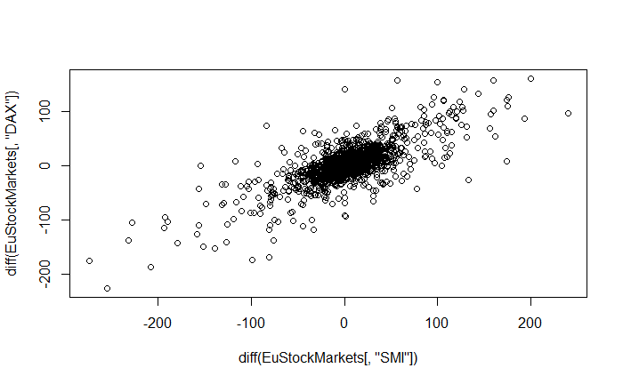

```r
plot(diff(EuStockMarkets[, "SMI"]), diff(EuStockMarkets[, "DAX"]))
```

```r
cor.test(diff(EuStockMarkets[, "SMI"]), diff(EuStockMarkets[, "DAX"]))
```

```
    Pearson's product-moment correlation

data:  diff(EuStockMarkets[, "SMI"]) and diff(EuStockMarkets[, "DAX"])
t = 48.396, df = 1857, p-value < 2.2e-16
alternative hypothesis: true correlation is not equal to 0
95 percent confidence interval:
 0.7260306 0.7662870
sample estimates:
      cor
0.7468422
```

Mesmo vale para correlaçao dos dados diferenciados.

Para saber se elas estão correlacionadas é descobrir se a mudança anterior no tempo de uma ação pode predizer a mudança posterior no tempo de outra ação. Para tal, recuamos uma das diferenças das ações em 1 antes de analisarmos o grafico de dispersão.

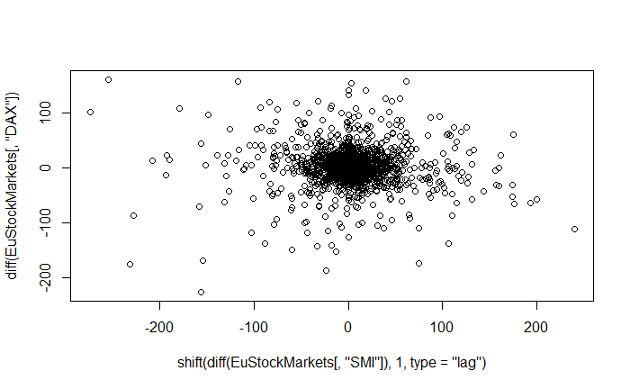

```r
plot(
  shift(diff(EuStockMarkets[, "SMI"]), 1, type='lag'),
  diff(EuStockMarkets[, "DAX"]))
```

```r
cor.test(
   shift(diff(EuStockMarkets[, "SMI"]), 1, type='lag'),
  diff(EuStockMarkets[, "DAX"])
)
```

```
    Pearson's product-moment correlation

data:  shift(diff(EuStockMarkets[, "SMI"]), 1, type = "lag") and diff(EuStockMarkets[, "DAX"])
t = -1.9144, df = 1856, p-value = 0.05573
alternative hypothesis: true correlation is not equal to 0
95 percent confidence interval:
 -0.089686927  0.001084998
sample estimates:
        cor
-0.04439259
```

Como p_valor > 0.05 aceito h_0 onde a correlaçao entre as duas variaveis não é estatisticamente significativa. Não posso afirmar que exites correlaçao entre duas variaveis.

# Métodos Exploratórios Específicos de séries temporais

## Compreendendo Estacionariedade

Muitos modelos estatisticos tradicionais de séries temporais dependem de uma série temporal estacionário. Grosso modo, uma série temporal estacionaria é aquela que tem propriedades estatísticas razoavelmente estáveis ao longo do tempo, sobretudo no que diz respeito a média e á variância.

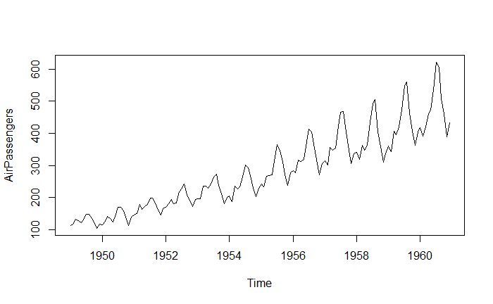

```r
plot(AirPassengers)
```

### Teste dickey fuller aumentado

$$H_0 : \text{possui raiz unitária, não é estacionaria} \\
H_a : \text{Não possui raiz unitaria é estacionária}$$

```r
adf.test(AirPassengers)
```

```
    Augmented Dickey-Fuller Test

data:  AirPassengers
Dickey-Fuller = -7.3186, Lag order = 5, p-value = 0.01
alternative hypothesis: stationary
```

### Teste KPSS

$$H_0 : \text{é estacionaria} \\
H_a : \text{não é estacionária}$$

```r
kpss.test(AirPassengers)
```

```
    KPSS Test for Level Stationarity

data:  AirPassengers
KPSS Level = 2.7395, Truncation lag parameter = 4, p-value = 0.01
```

### Pratica e realidade

É comum que um série temporal se torne estacionária o suficiente com algumas trasnformações simples :

- log transform
- sqrt transform
- BoxCox : outra suposiçao que modelos fazem é a normalização da distribuição das variaveis de entrada ou variavel predita.

### Funções de janela

#### Janela Rolante

Ela é particularmente útil quando você deseja calcular métricas (como médias, somas ou variâncias) ou aplicar modelos a subperíodos da série temporal para capturar padrões locais

```r
set.seed(seed = 10)
x = rnorm(n = 100, mean = 0, sd = 10) + 1:100

mn = function(n) rep(1/n, n)

plot(x, type = 'l', lwd=1)
lines(filter(x, mn(5)), col = 2, lwd = 3, lty = 2)
```

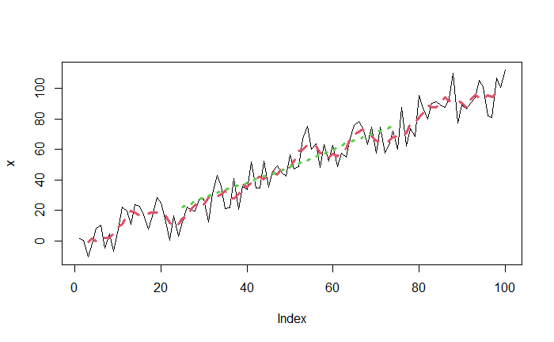

```r
lines(filter(x, mn(50)), col = 3, lwd = 3, lty = 3)
```

```r
filter(x, mn(5))
```

```
Time Series:
Start = 1
End = 100
Frequency = 1
  [1]          NA          NA -0.68291902  1.05917724  0.01152997  3.02683904  1.97182911  1.86978206  4.29375247  9.22146784
 [11] 10.47235276 16.70058753 19.69632457 18.67146010 16.25000937 17.33617571 18.21232883 18.69550563 18.32418982 16.86350385
 [21] 16.90407275 11.81490784  9.31855475 10.76385291 14.75931573 15.36472995 20.39933032 23.42216530 21.46200750 23.68122623
 [31] 28.36267657 29.93605050 28.68372440 30.52017659 32.40024318 27.94493699 27.92599705 30.38275823 36.42688975 35.17762554
 [41] 38.03847397 41.35650980 41.72433180 40.49359833 43.48373840 45.53864610 43.51446913 47.76022838 48.01658395 47.88242052
 [51] 52.22074579 58.85150916 59.55269242 62.92665228 62.79134152 62.12122760 57.55390489 58.12424133 55.07636763 56.96843897
 [61] 55.24199967 58.21401947 60.76479728 66.67223790 70.05597176 71.75419984 73.19945807 69.57406586 68.90365861 65.57142279
 [71] 65.43694901 64.87445239 65.38721934 67.97078747 68.87198793 71.10810331 70.44183313 77.46687829 77.30712184 80.82145286
 [81] 84.10801705 88.64449600 87.47980704 87.61181217 90.37666347 94.39191424 91.59082243 91.56242703 91.41205644 90.70956347
 [91] 87.40761371 93.08620049 95.42402686 94.41744599 92.58705619 95.23381842 94.21945770 96.48359978          NA          NA
```

```python
reticulate::repl_python()
import numpy as np
import pandas as pd
import matplotlib.pyplot as plt
```

```python
x = np.random.RandomState(10).normal(size=100)
x = pd.Series(x, name="x")
```

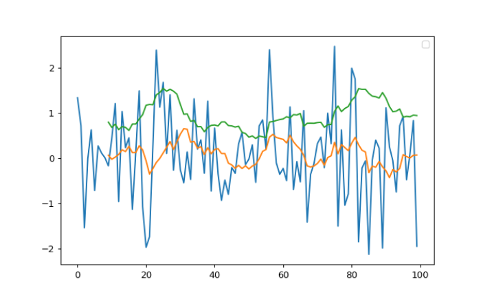

```python
plt.close()
plt.plot(range(100),x)
plt.plot(range(100),x.rolling(10).mean(), label='mean')
plt.plot(range(100),x.rolling(10).std(), label='std')
plt.legend(())
plt.show()
```

Imagine uma série temporal de temperaturas diárias. Se quisermos calcular a **média móvel de 7 dias**:

- Defina uma janela de 7 dias.
- Calcule a média dos primeiros 7 dias.
- Desloque a janela em 1 dia e repita o cálculo até o final da série.

## Self-Correlation

É em essencia a ideia que um valor em um série temporal em um determinado ponto no tempo pode estar correlaciona com o valor em outro ponto no tempo.

> mede como uma série temporal se relaciona consigo mesma em diferentes atrasos/defasagem no tempo(lags). É útil para identificar padrões repetitivos, como sazonalidade, tendências ou ciclos.

```python
x.autocorr(lag=1)
```

```
np.float64(-0.045748453430395776)
```

> Autocorrelação na defasagem de tempo 1 é -0.04

### Função de autocorrelação

É a correlação de um sinal com uma cópia atrasada de si mesmo.

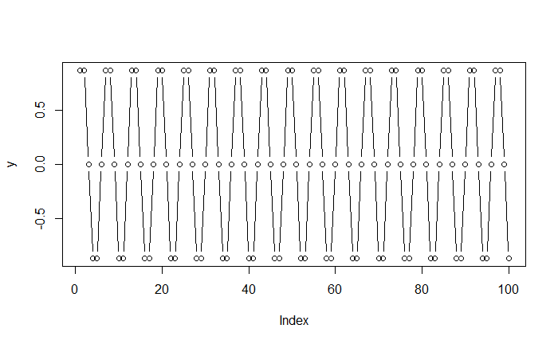

```r
x = 1:100
y = sin(x * pi/3)
plot(y, type='b')
```

[figure not shown]

```r
cor(y, shift(y, 1, type='lag'), use="pairwise.complete.obs")
```

```
[1] 0.5001531
```

> Quando a **Autocorrelação de uma Defasagem (ACF - AutoCorrelation Function)** ultrapassa um **threshold** (limite), significa que a correlação entre os valores da série temporal e seus valores defasados (lag) é estatisticamente significativa. Isso pode indicar a presença de padrões ou dependências na série temporal para aquela defasagem específica.